# Chemical links between redox conditions and community reference proteomes (2023)

This vignette runs the code to make the plots from the following paper first published by Springer Nature:

> Dick JM, Tan J. 2023. Chemical links between redox conditions and estimated community proteomes from 16S rRNA and reference protein sequences. *Microbial Ecology* **85**(4): 1338–1355. doi: 10.1007/s00248-022-01988-9

Use this link for full-text access to a view-only version of the paper: https://rdcu.be/cMCDa. A preprint of the paper is available on bioRxiv at doi: 10.1101/2021.05.31.446500.

This vignette was compiled on 2025-05-20 with **JMDplots** 1.2.22 and **chem16S** 1.2.0.

```r
library(JMDplots)
```

## Distinct chemical parameters of reference proteomes for major taxonomic groups (Figure 1)

```r
Table_S5 <- geo16S1()
```

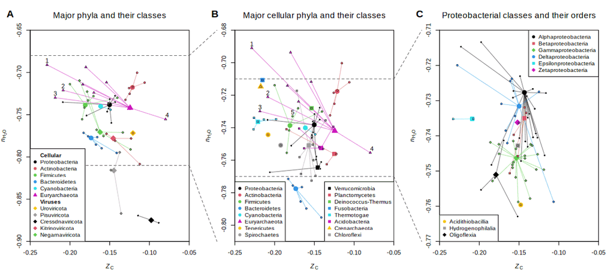

**Data source:** NCBI Reference Sequence (RefSeq) database (O’Leary et al., 2016). **Numbered symbols**: (1) Methanococci, (2) Archaeoglobi, (3) Thermococci, (4) Halobacteria, (5) Clostridia.

### Specific values mentioned in the text

*Z*<sub>C</sub> for reference proteomes of genera that are abundant in produced fluids of shale gas wells:

```r
datadir <- system.file("RefDB/RefSeq_206", package = "JMDplots")
taxon_metrics <- read.csv(file.path(datadir, "taxon_metrics.csv.xz"), as.is = TRUE)
subset(taxon_metrics, group %in% c("Halanaerobium", "Thermoanaerobacter"))
```

```
##      rank              group ntaxa                  parent      nH2O        Zc
## 337 genus Thermoanaerobacter    15 Thermoanaerobacteraceae -0.695134 -0.227056
## 483 genus      Halanaerobium     9        Halanaerobiaceae -0.716348 -0.198702
##           nC
## 337 5.105583
## 483 5.080626
```

*Z*<sub>C</sub> for reference proteomes of *Halanaerobium* species (numeric names are NCBI taxids):

```r
datadir <- system.file("RefDB/RefSeq_206", package = "JMDplots")
refseq <- read.csv(file.path(datadir, "genome_AA.csv.xz"))
Zc.refseq <- Zc(refseq)
names(Zc.refseq) <- refseq$organism

names <- read.csv(file.path(datadir, "taxonomy.csv.xz"))
is.Halanaerobium <- names$genus %in% "Halanaerobium" & !is.na(names$species)
(Zc.Halanaerobium <- round(Zc.refseq[is.Halanaerobium], 3))
```

```
##    2331   29563   43595   54121   56779  656519 1653064 2183913 2183914
##  -0.214  -0.207  -0.191  -0.191  -0.194  -0.196  -0.202  -0.202  -0.194
```

```r
range(Zc.Halanaerobium)
```

```
## [1] -0.214 -0.191
```

## Estimated community proteomes from different environments have distinct chemical signatures (Figure 2)

```r
Table_S6 <- geo16S2()
```

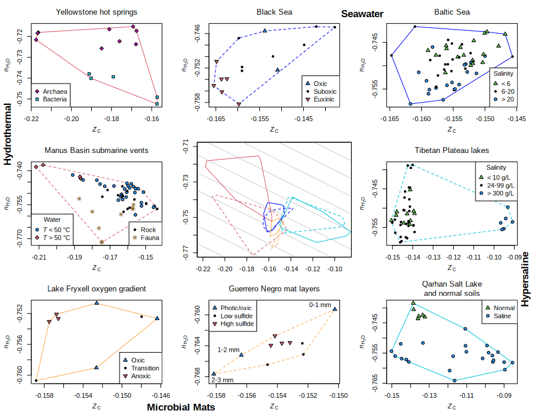

**Data sources:** Guerrero Negro mat (Harris et al., 2013), Yellowstone hot springs (Bowen De León et al., 2013), Baltic Sea water (Herlemann et al., 2016), Lake Fryxell mat (Jungblut et al., 2016), Tibetan Plateau lakes (Zhong et al., 2016), Manus Basin vents (Meier et al., 2017), Qarhan Salt Lake soils (Xie et al., 2017), Black Sea water (Sollai et al., 2019).

## Lower carbon oxidation state is tied to oxygen depletion in water columns (Figure 3)

```r
Table_S7 <- geo16S3()
```

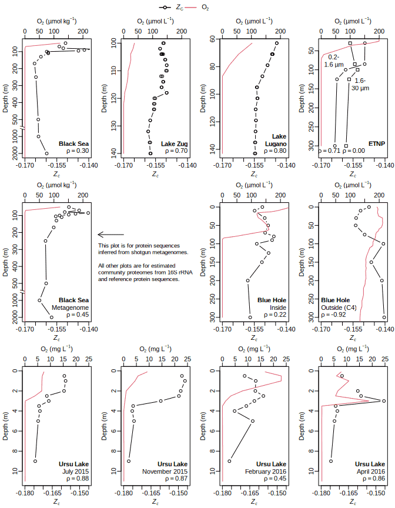

**Data sources:** Black Sea (Sollai et al., 2019), Swiss lakes (Lake Zug and Lake Lugano) (Mayr et al., 2020), Eastern Tropical North Pacific (ETNP) (Ganesh et al., 2015), Sansha Yongle Blue Hole (He et al., 2020), Ursu Lake (Baricz et al., 2021).

## Common trends of carbon oxidation state of estimated community proteomes for shale gas wells and hydrothermal systems (Figure 4)

```r
Table_S8 <- geo16S4()
```

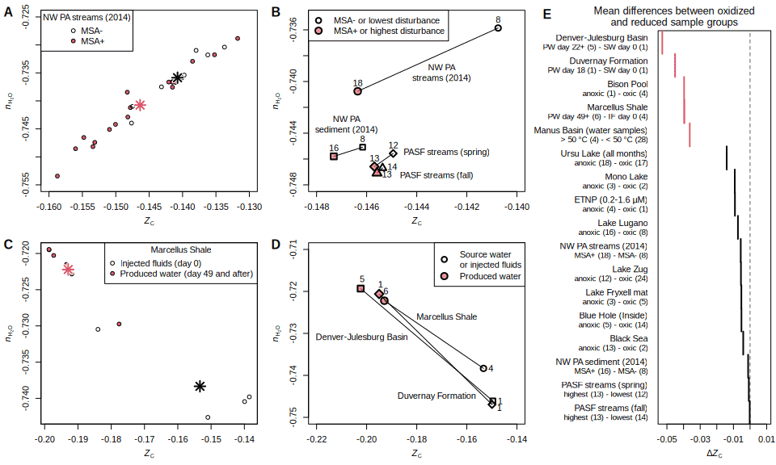

**Data sources:** Northwestern Pennsylvania stream water and sediment (Ulrich et al., 2018), Pennsylvania State Forests stream water in spring and fall (Mumford et al., 2020), Marcellus Shale (Cluff et al., 2014), Denver–Julesburg Basin (Hull et al., 2018), Duvernay Formation (Zhong et al., 2019).

## Comparison of protein *Z*<sub>C</sub> from metagenomic or metatranscriptomic data with estimates from 16S and reference sequences (Figure 5)

```r
Table_S9 <- geo16S5()
```

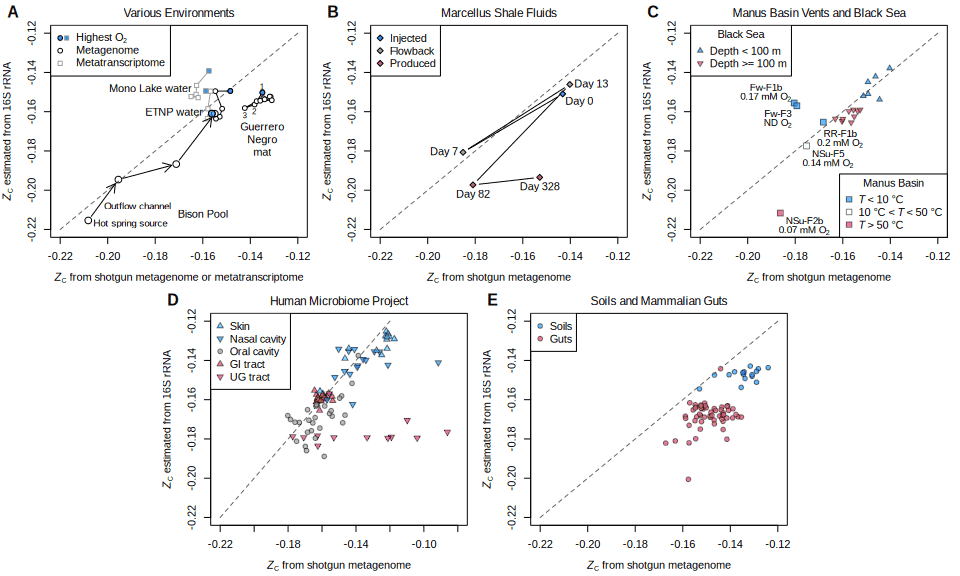

**Data sources:** **A**. Guerrero Negro mat metagenome (Kunin et al., 2008), 16S (Harris et al., 2013); Bison Pool metagenome (Havig et al., 2011), 16S (Swingley et al., 2012); Eastern Tropical North Pacific metagenome (Glass et al., 2015), metatranscriptome and 16S (Ganesh et al., 2015); Mono Lake metatranscriptome (Edwardson and Hollibaugh, 2017), 16S (Edwardson and Hollibaugh, 2018). **B**. Marcellus Shale metagenome (Daly et al., 2016), 16S (Cluff et al., 2014). **C**. Manus Basin vents (Meier et al., 2017), Black Sea metagenome (Villanueva et al., 2021), 16S (Sollai et al., 2019). **D**. Human Microbiome Project (The Human Microbiome Project Consortium, 2012). **E**. Soils (Fierer et al., 2012); mammalian guts (Muegge et al., 2011).

## RefSeq and 16S rRNA data processing outline (Figure S1)

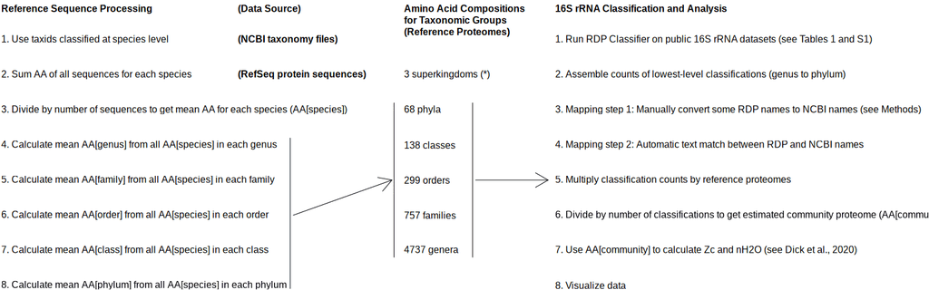

```r
geo16S_S1()
```

## Scatterplots of *Z*<sub>C</sub> and *n*H<sub>2</sub>O for bacterial and archaeal genera vs higher taxonomic levels (Figure S2)

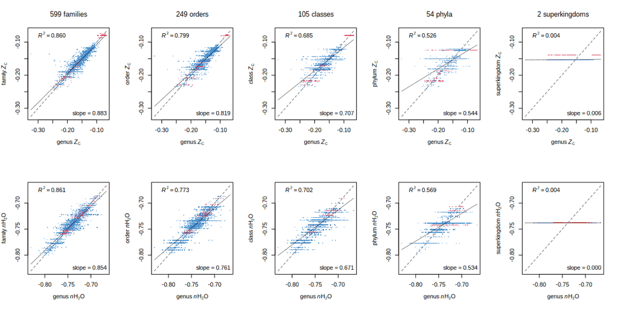

```r
geo16S_S2()
```

## *n*H<sub>2</sub>O-*Z*<sub>C</sub> plots for major phyla and their genera (Figure S3)

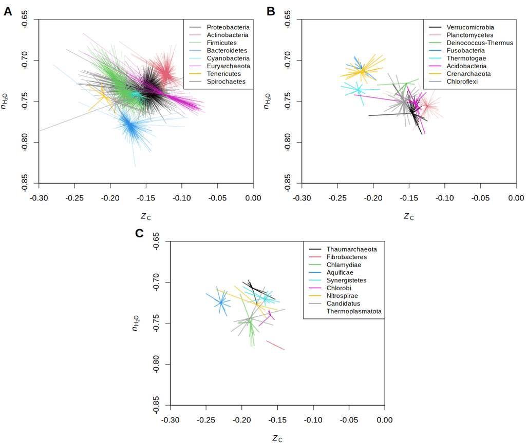

```r
geo16S_S3()
```

## Venn diagrams for phylum and genus names in the RefSeq (NCBI), RDP, and SILVA taxonomies (Figure S4)

```r
Table_S10 <- geo16S_S4()
```

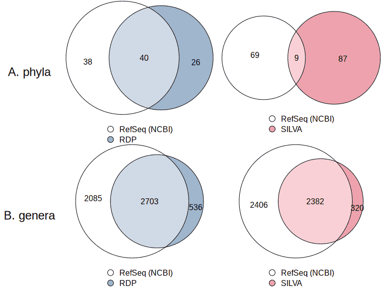

**Data sources:** **RefSeq (NCBI):** Names of taxa with protein sequences in RefSeq as listed in `system.file("RefDB/RefSeq_206/taxonomy.csv.xz", package = "JMDplots")`; **RDP:** `trainset18_062020_speciesrank.fa` in https://sourceforge.net/projects/rdp-classifier/files/RDP_Classifier_TrainingData/RDPClassifier_16S_trainsetNo18_rawtrainingdata.zip; **SILVA:** https://www.arb-silva.de/fileadmin/silva_databases/release_138_1/Exports/SILVA_138.1_SSURef_NR99_tax_silva.fasta.gz.

## Correlations between *Z*<sub>C</sub> estimated from metagenomes and 16S rRNA sequences (Figure S5)

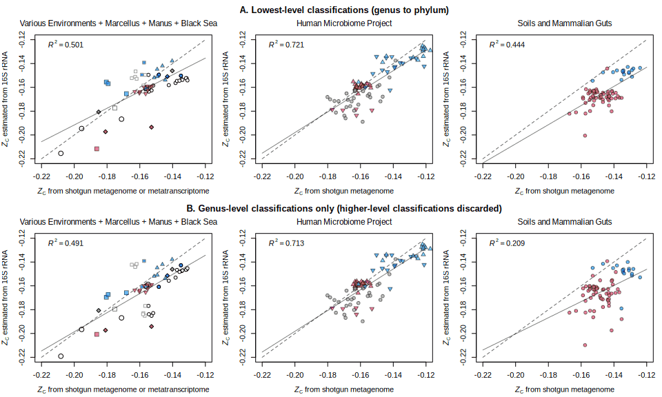

```r
geo16S_S5()
```

## Correlation of *Z*<sub>C</sub> with GC content of metagenomic and 16S amplicon reads (Figure S6)

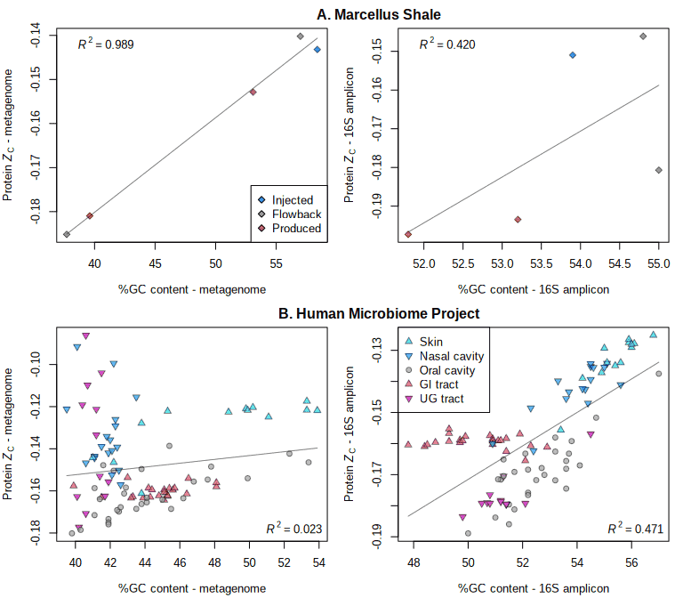

```r
geo16S_S6()
```

**Data source:** https://trace.ncbi.nlm.nih.gov/Traces/sra/?run=SRR*******, where `SRR*******` is the SRA Run accession for metagenomic or 16S amplicon sequences.

## Supplementary Table files

```r
write.csv(Table_S5, "Table_S5.csv", row.names = FALSE, quote = FALSE)
write.csv(Table_S6, "Table_S6.csv", row.names = FALSE, quote = FALSE)
write.csv(Table_S7, "Table_S7.csv", row.names = FALSE, quote = FALSE)
write.csv(Table_S8, "Table_S8.csv", row.names = FALSE, quote = FALSE)
write.csv(Table_S9, "Table_S9.csv", row.names = FALSE, quote = FALSE)
write.csv(Table_S10, "Table_S10.csv", row.names = FALSE, quote = FALSE)
```

## References

Baricz A, Chiriac CM, Andrei A-Ş, Bulzu P-A, Levei EA, Cadar O, Battes KP, Cîmpean M, Şenilă M, Cristea A, et al. 2021. Spatio-temporal insights into microbiology of the freshwater-to-hypersaline, oxic-hypoxic-euxinic waters of Ursu Lake. *Environmental Microbiology* **23**(7): 3523–3540. doi: 10.1111/1462-2920.14909

Bowen De León K, Gerlach R, Peyton BM, Fields MW. 2013. Archaeal and bacterial communities in three alkaline hot springs in Heart Lake Geyser Basin, Yellowstone National Park. *Frontiers in Microbiology* **4**: 330. doi: 10.3389/fmicb.2013.00330

Cluff MA, Hartsock A, MacRae JD, Carter K, Mouser PJ. 2014. Temporal changes in microbial ecology and geochemistry in produced water from hydraulically fractured Marcellus Shale gas wells. *Environmental Science & Technology* **48**(11): 6508–6517. doi: 10.1021/es501173p

Daly RA, Borton MA, Wilkins MJ, Hoyt DW, Kountz DJ, Wolfe RA, Welch SA, Marcus DN, Trexler RV, MacRae JD, et al. 2016. Microbial metabolisms in a 2.5-km-deep ecosystem created by hydraulic fracturing in shales. *Nature Microbiology* **1**: 16146. doi: 10.1038/nmicrobiol.2016.146

Edwardson CF, Hollibaugh JT. 2017. Metatranscriptomic analysis of prokaryotic communities active in sulfur and arsenic cycling in Mono Lake, California, USA. *The ISME Journal* **11**: 2195–2208. doi: 10.1038/ismej.2017.80

Edwardson CF, Hollibaugh JT. 2018. Composition and activity of microbial communities along the redox gradient of an alkaline, hypersaline, lake. *Frontiers in Microbiology* **9**: 14. doi: 10.3389/fmicb.2018.00014

Fierer N, Leff JW, Adams BJ, Nielsen UN, Bates ST, Lauber CL, Owens S, Gilbert JA, Wall DH, Caporaso JG. 2012. Cross-biome metagenomic analyses of soil microbial communities and their functional attributes. *Proceedings of the National Academy of Sciences* **109**(52): 21390–21395. doi: 10.1073/pnas.1215210110

Ganesh S, Bristow LA, Larsen M, Sarode N, Thamdrup B, Stewart FJ. 2015. Size-fraction partitioning of community gene transcription and nitrogen metabolism in a marine oxygen minimum zone. *The ISME Journal* **9**(12): 2682–2696. doi: 10.1038/ismej.2015.44

Glass JB, Kretz CB, Ganesh S, Ranjan P, Seston SL, Buck KN, Landing WM, Morton PL, Moffett JW, Giovannoni SJ, et al. 2015. Meta-omic signatures of microbial metal and nitrogen cycling in marine oxygen minimum zones. *Frontiers in Microbiology* **6**: 998. doi: 10.3389/fmicb.2015.00998

Harris JK, Caporaso JG, Walker JJ, Spear JR, Gold NJ, Robertson CE, Hugenholtz P, Goodrich J, McDonald D, Knights D, et al. 2013. Phylogenetic stratigraphy in the Guerrero Negro hypersaline microbial mat. *The ISME Journal* **7**(1): 50–60. doi: 10.1038/ismej.2012.79

Havig JR, Raymond J, Meyer-Dombard DR, Zolotova N, Shock EL. 2011. Merging isotopes and community genomics in a siliceous sinter-depositing hot spring. *Journal of Geophysical Research* **116**: G01005. doi: 10.1029/2010JG001415

He P, Xie L, Zhang X, Li J, Lin X, Pu X, Yuan C, Tian Z, Li J. 2020. Microbial diversity and metabolic potential in the stratified Sansha Yongle Blue Hole in the South China Sea. *Scientific Reports* **10**(1): 5949. doi: 10.1038/s41598-020-62411-2

Herlemann DPR, Lundin D, Andersson AF, Labrenz M, Jürgens K. 2016. Phylogenetic signals of salinity and season in bacterial community composition across the salinity gradient of the Baltic Sea. *Frontiers in Microbiology* **7**: 1883. doi: 10.3389/fmicb.2016.01883

Hull NM, Rosenblum JS, Robertson CE, Harris JK, Linden KG. 2018. Succession of toxicity and microbiota in hydraulic fracturing flowback and produced water in the Denver–Julesburg Basin. *Science of The Total Environment* **644**: 183–192. doi: 10.1016/j.scitotenv.2018.06.067

Jungblut AD, Hawes I, Mackey TJ, Krusor M, Doran PT, Sumner DY, Eisen JA, Hillman C, Goroncy AK. 2016. Microbial mat communities along an oxygen gradient in a perennially ice-covered Antarctic lake. *Applied and Environmental Microbiology* **82**(2): 620–630. doi: 10.1128/AEM.02699-15

Kunin V, Raes J, Harris JK, Spear JR, Walker JJ, Ivanova N, Mering C von, Bebout BM, Pace NR, Bork P, et al. 2008. Millimeter-scale genetic gradients and community-level molecular convergence in a hypersaline microbial mat. *Molecular Systems Biology* **4**: 198. doi: 10.1038/msb.2008.35

Mayr MJ, Zimmermann M, Guggenheim C, Brand A, Bürgmann H. 2020. Niche partitioning of methane-oxidizing bacteria along the oxygen-methane counter gradient of stratified lakes. *The ISME Journal* **14**(1): 274–287. doi: 10.1038/s41396-019-0515-8

Meier DV, Pjevac P, Bach W, Hourdez S, Girguis PR, Vidoudez C, Amann R, Meyerdierks A. 2017. Niche partitioning of diverse sulfur-oxidizing bacteria at hydrothermal vents. *The ISME Journal* **11**: 1545–1558. doi: 10.1038/ismej.2017.37

Muegge BD, Kuczynski J, Knights D, Clemente JC, González A, Fontana L, Henrissat B, Knight R, Gordon JI. 2011. Diet drives convergence in gut microbiome functions across mammalian phylogeny and within humans. *Science* **332**(6032): 970–974. doi: 10.1126/science.1198719

Mumford AC, Maloney KO, Akob DM, Nettemann S, Proctor A, Ditty J, Ulsamer L, Lookenbill J, Cozzarelli IM. 2020. Shale gas development has limited effects on stream biology and geochemistry in a gradient-based, multiparameter study in Pennsylvania. *Proceedings of the National Academy of Sciences* **117**(7): 3670–3677. doi: 10.1073/pnas.1911458117

O’Leary NA, Wright MW, Brister JR, Ciufo S, Haddad D, McVeigh R, Rajput B, Robbertse B, Smith-White B, Ako-Adjei D, et al. 2016. Reference sequence (RefSeq) database at NCBI: Current status, taxonomic expansion, and functional annotation. *Nucleic Acids Research* **44**(D1): D733–D745. doi: 10.1093/nar/gkv1189

Sollai M, Villanueva L, Hopmans EC, Reichart G-J, Sinninghe Damsté JS. 2019. A combined lipidomic and 16S rRNA gene amplicon sequencing approach reveals archaeal sources of intact polar lipids in the stratified Black Sea water column. *Geobiology* **17**(1): 91–109. doi: 10.1111/gbi.12316

Swingley WD, Meyer-Dombard DR, Shock EL, Alsop EB, Falenski HD, Havig JR, Raymond J. 2012. Coordinating environmental genomics and geochemistry reveals metabolic transitions in a hot spring ecosystem. *PLOS One* **7**(6): e38108. doi: 10.1371/journal.pone.0038108

The Human Microbiome Project Consortium. 2012. Structure, function and diversity of the healthy human microbiome. *Nature* **486**(7402): 207–214. doi: 10.1038/nature11234

Ulrich N, Kirchner V, Drucker R, Wright JR, McLimans CJ, Hazen TC, Campa MF, Grant CJ, Lamendella R. 2018. Response of aquatic bacterial communities to hydraulic fracturing in northwestern Pennsylvania: A five-year study. *Scientific Reports* **8**(1): 5683. doi: 10.1038/s41598-018-23679-7

Villanueva L, Meijenfeldt FAB von, Westbye AB, Yadav S, Hopmans EC, Dutilh BE, Damsté JSS. 2021. Bridging the membrane lipid divide: Bacteria of the FCB group superphylum have the potential to synthesize archaeal ether lipids. *The ISME Journal* **15**(1): 168–182. doi: 10.1038/s41396-020-00772-2

Xie KH, Deng Y, Zhang SC, Zhang WH, Liu JR, Xie YL, Zhang XZ, Huang H. 2017. Prokaryotic community distribution along an ecological gradient of salinity in surface and subsurface saline soils. *Scientific Reports* **7**: 13332. doi: 10.1038/s41598-017-13608-5

Zhong C, Li J, Flynn SL, Nesbø CL, Sun C, Gunten K von, Lanoil BD, Goss GG, Martin JW, Alessi DS. 2019. Temporal changes in microbial community composition and geochemistry in flowback and produced water from the Duvernay formation. *ACS Earth and Space Chemistry* **3**(6): 1047–1057. doi: 10.1021/acsearthspacechem.9b00037

Zhong Z-P, Liu Y, Miao L-L, Wang F, Chu L-M, Wang J-L, Liu Z-P. 2016. Prokaryotic community structure driven by salinity and ionic concentrations in plateau lakes of the Tibetan Plateau. *Applied and Environmental Microbiology* **82**(6): 1846–1858. doi: 10.1128/AEM.03332-15